# Data Science project based on real dataset

The aim of the project is to demonstrate Data Science skills gained after education on Datacamp.com

## 1. Import related modules

```python
import numpy as np
import pandas as pd
import datetime as dt
import matplotlib.pyplot as plt
import seaborn as sns

# + K-means
from sklearn.preprocessing import StandardScaler
from sklearn.cluster import KMeans
```

## 2. Import and clean the data set.

Meaning of each data set

**FB-01.csv:** real dataset imported from Facebook Ads. Contains daily historical advertising data from Jan 2021 to Dec 2021  
**crm.csv:** real dataset imported from RetailCRM. Contains daily historical sales data from Jan 2021 to Dec 2021. All real names of customers were encrypted using random key

```python
facebook = pd.read_csv('csv/FB-01.csv')
sales = pd.read_csv('csv/crm.csv', sep=';')
```

#### Defining a function to help to explore data

```python
def basic_information(df):
    print('----------------The first 5 rows of data----------------')
    print(df.head())
    print('----------------Brief summary----------------')
    print(df.info())
    print('----------------Data set size----------------')
    print(df.shape)
    print('----------------Column name----------------')
    print(df.columns)
    print('----------------Numerical features----------------')
    print(df.describe())
    print('----------------Missing data----------------')
    print(df.isnull().sum())
```

```python
basic_information(facebook)
```

```
----------------The first 5 rows of data----------------
         День                         Название группы объявлений  \
0  2021-12-31                                               Базы
1  2021-12-31                  Похожие - Клиенты - 3 месяца - 3%
2  2021-12-31                                       Уличная мода
3  2021-12-31  Купальники взаимодействовали — Копия — Копия —...
4  2021-12-31                                             Одежда

    Статус показа Уровень показа  \
0  not_delivering          adset
1  not_delivering          adset
2  not_delivering          adset
3          active          adset
4  not_delivering          adset

                                   Название кампании    Тип результата  \
0                   [m] Lal перезапуск по источникам  Начата переписка
1                                   Кроп-топы заново  Начата переписка
2  [m] Рекламные кампании на новые креативы перез...  Начата переписка
3                             Взаимодействия - дубль  Начата переписка
4                           [m] ПРямые №2 перезапуск  Начата переписка

   Результат  Охват  Показы  Цена за результат  Сумма затрат (USD)  \
0        1.0   1345    1462              4.830                4.83
1        2.0   6018    6534              7.075               14.15
2        2.0   4982    5264              4.540                9.08
3        NaN   4777    5392                NaN               10.81
4        1.0   7252    7517             10.850               10.85

   Покупки на сайте   Частота  Уникальные клики по ссылке  \
0               NaN  1.086989                         1.0
1               NaN  1.085743                        10.0
2               NaN  1.056604                         6.0
3               NaN  1.128742                         6.0
4               NaN  1.036542                        10.0

   Просмотры целевой страницы  Клики по ссылке Дата начала отчетности  \
0                         NaN              1.0             2021-12-31
1                         NaN             10.0             2021-12-31
2                         NaN              6.0             2021-12-31
```

[output cut: 81 more lines]

```
Название кампании                0
Тип результата                   0
Результат                     2141
Охват                            0
Показы                           0
Цена за результат             2143
Сумма затрат (USD)               0
Покупки на сайте              4813
Частота                          0
Уникальные клики по ссылке    1016
Просмотры целевой страницы    4813
Клики по ссылке               1016
Дата начала отчетности           0
Дата окончания отчетности        0
dtype: int64
```

```python
basic_information(sales)
```

```
----------------The first 5 rows of data----------------
                             Покупатель   Сумма  Номер      Дата и время  \
0                      Аdf2322fav24rfdv   799.0  33998  31.12.2021 15:26
1  Бzcdfdу2123dv22zcacft22avrlАdfzc24av   799.0  33997  31.12.2021 15:19
2                          Вavdf23dvpqw  6494.0  33996  31.12.2021 14:11
3                  Кdу28уmrlКavdvzc24av   799.0  33995  31.12.2021 13:52
4                              spav24av  1359.0  33994  31.12.2021 13:23

  Статус заказа Способ оформления
0      Выполнен            Шоурум
1      Выполнен       В один клик
2      Выполнен            Шоурум
3      Выполнен          intertop
4      Выполнен            Шоурум
----------------Brief summary----------------
<class 'pandas.core.frame.DataFrame'>
RangeIndex: 10819 entries, 0 to 10818
Data columns (total 6 columns):
 #   Column             Non-Null Count  Dtype
---  ------             --------------  -----
 0   Покупатель         10818 non-null  object
 1   Сумма              10819 non-null  float64
 2   Номер              10819 non-null  int64
 3   Дата и время       10819 non-null  object
 4   Статус заказа      10819 non-null  object
 5   Способ оформления  10819 non-null  object
dtypes: float64(1), int64(1), object(4)
memory usage: 507.3+ KB
None
----------------Data set size----------------
(10819, 6)
----------------Column name----------------
Index(['Покупатель', 'Сумма', 'Номер', 'Дата и время', 'Статус заказа',
       'Способ оформления'],
      dtype='object')
----------------Numerical features----------------
              Сумма         Номер
count  10819.000000  10819.000000
mean     842.705658  28549.270820
std     1350.306646   3165.687331
min        0.000000  23074.000000
25%      460.000000  25780.500000
50%      680.000000  28583.000000
75%     1069.000000  31293.500000
max    51671.000000  33998.000000
----------------Missing data----------------
Покупатель           1
Сумма                0
Номер                0
Дата и время         0
Статус заказа        0
Способ оформления    0
dtype: int64
```

#### Clearing and filtering the data

```python
#droping unnecessary columns
facebook = facebook.drop(facebook.columns[[2, 3, 4, 8, 9, 10, 11, 12, 13, 14, 15, 16, 17]], axis=1)
#Changing NaN to 0
facebook = facebook.fillna(0)
sales = sales.fillna(0)
#Converting object type to datetime
facebook['День'] = pd.to_datetime(facebook['День'])
sales['Дата и время'] = pd.to_datetime(sales['Дата и время'])
#Converting float to int
facebook['Результат'] =facebook['Результат'].astype(int)
```

```python
# Deleting rows with 'Тип результата' not 'Начата переписка' I'll analyse only Instagram ads
facebook = facebook.loc[facebook['Тип результата'] == 'Начата переписка']
#We need to analyse only completed orders
sales = sales.loc[sales['Статус заказа'] == 'Выполнен']
# and droping that columns
facebook = facebook.drop('Тип результата', axis=1)
sales = sales.drop('Статус заказа', axis=1)

# A typical customer can make purchaises up to 5000 UAH per year. Minimal price of goods - 400 UAH.
# Let's clean unuseful data!

sales = sales.loc[(sales['Сумма'] > 400) & (sales['Сумма'] < 5000)]
```

#### Adding aditional columns

```python
# I need to analyse monthly dynamics. Lets ad some usefull columns.

facebook['EventMonth'] = facebook['День'].dt.month
sales['EventMonth'] = sales['Дата и время'].dt.month
```

### Lets take a look at the datasets once more

```python
basic_information(facebook)
```

```
----------------The first 5 rows of data----------------
        День                         Название группы объявлений  Результат  \
0 2021-12-31                                               Базы          1
1 2021-12-31                  Похожие - Клиенты - 3 месяца - 3%          2
2 2021-12-31                                       Уличная мода          2
3 2021-12-31  Купальники взаимодействовали — Копия — Копия —...          0
4 2021-12-31                                             Одежда          1

   Охват  EventMonth
0   1345          12
1   6018          12
2   4982          12
3   4777          12
4   7252          12
----------------Brief summary----------------
<class 'pandas.core.frame.DataFrame'>
Int64Index: 4255 entries, 0 to 4809
Data columns (total 5 columns):
 #   Column                      Non-Null Count  Dtype
---  ------                      --------------  -----
 0   День                        4255 non-null   datetime64[ns]
 1   Название группы объявлений  4255 non-null   object
 2   Результат                   4255 non-null   int32
 3   Охват                       4255 non-null   int64
 4   EventMonth                  4255 non-null   int64
dtypes: datetime64[ns](1), int32(1), int64(2), object(1)
memory usage: 182.8+ KB
None
----------------Data set size----------------
(4255, 5)
----------------Column name----------------
Index(['День', 'Название группы объявлений', 'Результат', 'Охват',
       'EventMonth'],
      dtype='object')
----------------Numerical features----------------
         Результат         Охват   EventMonth
count  4255.000000   4255.000000  4255.000000
mean      1.499882   2846.033137     7.713749
std       2.227629   3080.994330     3.207425
min       0.000000      0.000000     1.000000
25%       0.000000    611.500000     5.000000
50%       1.000000   1915.000000     8.000000
75%       2.000000   4026.500000    11.000000
max      21.000000  31775.000000    12.000000
----------------Missing data----------------
День                          0
Название группы объявлений    0
Результат                     0
Охват                         0
EventMonth                    0
dtype: int64
```

```python
basic_information(sales)
```

```
----------------The first 5 rows of data----------------
                                      Покупатель   Сумма  Номер  \
0                               Аdf2322fav24rfdv   799.0  33998
1           Бzcdfdу2123dv22zcacft22avrlАdfzc24av   799.0  33997
3                           Кdу28уmrlКavdvzc24av   799.0  33995
4                                       spav24av  1359.0  33994
6  Кf2324rf28dуacavrlОdft25avrlВp22idуdvdуac24av  2598.0  33992

         Дата и время Способ оформления  EventMonth
0 2021-12-31 15:26:00            Шоурум          12
1 2021-12-31 15:19:00       В один клик          12
3 2021-12-31 13:52:00          intertop          12
4 2021-12-31 13:23:00            Шоурум          12
6 2021-12-31 08:32:00           Корзина          12
----------------Brief summary----------------
<class 'pandas.core.frame.DataFrame'>
Int64Index: 7680 entries, 0 to 10815
Data columns (total 6 columns):
 #   Column             Non-Null Count  Dtype
---  ------             --------------  -----
 0   Покупатель         7680 non-null   object
 1   Сумма              7680 non-null   float64
 2   Номер              7680 non-null   int64
 3   Дата и время       7680 non-null   datetime64[ns]
 4   Способ оформления  7680 non-null   object
 5   EventMonth         7680 non-null   int64
dtypes: datetime64[ns](1), float64(1), int64(2), object(2)
memory usage: 420.0+ KB
None
----------------Data set size----------------
(7680, 6)
----------------Column name----------------
Index(['Покупатель', 'Сумма', 'Номер', 'Дата и время', 'Способ оформления',
       'EventMonth'],
      dtype='object')
----------------Numerical features----------------
             Сумма         Номер   EventMonth
count  7680.000000   7680.000000  7680.000000
mean   1009.751818  28542.678255     6.526953
std     606.502312   3243.590242     3.513752
min     403.000000  23077.000000     1.000000
25%     599.000000  25628.250000     3.000000
50%     799.000000  28611.500000     7.000000
75%    1240.000000  31431.250000    10.000000
max    4997.000000  33998.000000    12.000000
----------------Missing data----------------
Покупатель           0
Сумма                0
Номер                0
Дата и время         0
Способ оформления    0
EventMonth           0
dtype: int64
```

### Clean and good-looking data without errors. Now we can analyze it.

#### Let's take a look at monthly coverage and monthly conversion of ads

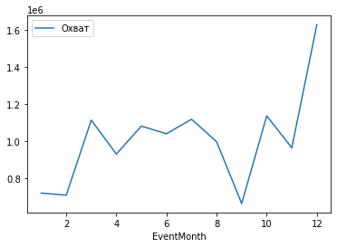

```python
monthly_coverage  = facebook.groupby(['EventMonth'])[['Охват']].sum()
monthly_coverage.plot()
```

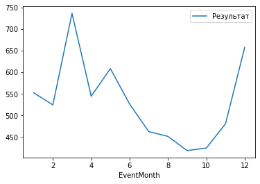

```python
monthly_conversion = facebook.groupby(['EventMonth'])[['Результат']].sum()
monthly_conversion.plot()
```

There is a strong dynamics mismatch in the 7th and 10-11th months. This is due to events that are not seen on the chart.  
7th - technical failures in the ads account  
10th - traditional seasonal sales decrease in those categories of goods  
11th - black friday (high discounts generate high conversions)

#### Now let's compare the dynamics of ads conversions with the sales dynamics

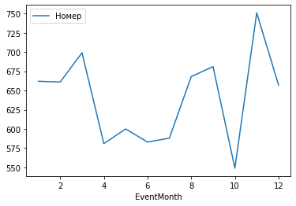

```python
sales_orders_permonth  = sales.groupby(['EventMonth'])[['Номер']].count()
sales_orders_permonth.plot()
```

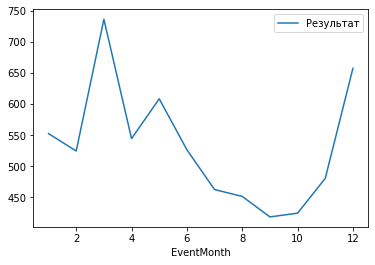

```python
monthly_conversion.plot()
```

We can observe a weak correlation between sales conversion and ads conversion.  
The volume of sales is greater than the volume of conversions.  
It means that other tools were used to increase sales.  
In some months it synergistically increased sales (month 3 and month 11)  
In some months it was turned off or didn't worked as it should

#### Lets count convertion rate

```python
fb_ads_conv_rate  = monthly_coverage.merge(monthly_conversion, how='left', on='EventMonth')
fb_ads_conv_rate['Конверсия'] = fb_ads_conv_rate['Результат'] / fb_ads_conv_rate['Охват']
fb_ads_conv_rate['Конверсия'] = fb_ads_conv_rate['Конверсия'] * 100
fb_ads_conv_rate['Конверсия'] = fb_ads_conv_rate['Конверсия'].round(3)
fb_ads_conv_rate.head(12)
```

| EventMonth | Охват | Результат | Конверсия |
| --- | --- | --- | --- |
| 1 | 721745 | 552 | 0.076 |
| 2 | 710548 | 524 | 0.074 |
| 3 | 1113659 | 736 | 0.066 |
| 4 | 931609 | 544 | 0.058 |
| 5 | 1081707 | 608 | 0.056 |
| 6 | 1040421 | 526 | 0.051 |
| 7 | 1118418 | 462 | 0.041 |
| 8 | 997784 | 451 | 0.045 |
| 9 | 665684 | 418 | 0.063 |
| 10 | 1136448 | 424 | 0.037 |
| 11 | 965066 | 480 | 0.050 |
| 12 | 1626782 | 657 | 0.040 |

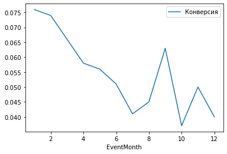

```python
fb_ads_conv_rate.plot(y='Конверсия')
```

I can find the following conclusions (considering that the quality of other ads parameters were not worsened):  
1) The drop in conversion in the 3rd-7th month happened due to the iOS 14.5 update  
2) 8th month - facebook learned how to work with such data and the conversion began to recoup  
3) 9th month - a sharp rise cosed by unknown factor  
4) 10th month - seasonal sales decrease  
5) 12th month - decrease caused by external factors (advertising budget increased, a lot of experiments were started)

## RFM analysis

```python
#calculate unique customers
unique_customers = sales['Покупатель'].nunique()
print(unique_customers)
```

```
6267
```

```python
# total customers per month
total_clients_per_month = sales.groupby(['EventMonth'])['Покупатель'].count()
total_clients_per_month.head()
```

```
EventMonth
1    662
2    661
3    699
4    581
5    600
Name: Покупатель, dtype: int64
```

```python
# unique customers per month
x = total_clients_per_month  / unique_customers
x.head()
```

```
EventMonth
1    0.105633
2    0.105473
3    0.111537
4    0.092708
5    0.095740
Name: Покупатель, dtype: float64
```

```python
#Create a function by passing a datetime object extracting year, month from x
def get_month(x): return dt.datetime(x.year, x.month, 1)
# Create InvoiceMonth column
sales['InvoiceMonth'] = sales['Дата и время'].apply(get_month)
# Group by Customer and select the InvoiceMonth value
grouping = sales.groupby('Покупатель')['InvoiceMonth']
# Assign a minimum InvoiceMonth value to the dataset
sales['CohortMonth'] = grouping.transform('min')

#Create a function by passing a datetime object extracting year, month from x
def get_day(x): return dt.datetime(x.year, x.month, x.day)
# Create InvoiceDay column
sales['InvoiceDay'] = sales['Дата и время'].apply(get_day)
# Group by Customer and select the InvoiceDay value
grouping = sales.groupby('Покупатель')['InvoiceDay']
# Assign a minimum InvoiceDay value to the dataset
sales['CohortDay'] = grouping.transform('min')
```

```python
#create 6 variables that capture the integer value of years, months and days for Invoice and Cohort Date
def get_date_int(df, column):
    year = df[column].dt.year
    month = df[column].dt.month
    day = df[column].dt.day
    return year, month, day

# Get the integers for date parts from the `InvoiceMonth` column
invoice_year, invoice_month, invoice_day = get_date_int(sales, 'InvoiceMonth')

# Get the integers for date parts from the `CohortMonth` column
cohort_year, cohort_month, cohort_day = get_date_int(sales, 'CohortMonth')

# Get the integers for date parts from the `InvoiceDay` column
invoice_year, invoice_month, invoice_day = get_date_int(sales, 'InvoiceDay')

# Get the integers for date parts from the `CohortDay` column
cohort_year, cohort_month, cohort_day = get_date_int(sales, 'CohortDay')
```

```python
# Calculate difference in years
years_diff = invoice_year - cohort_year

# Calculate difference in months
months_diff = invoice_month - cohort_month

# Calculate difference in day
day_diff = invoice_day - cohort_day

# Extract the difference in month from all previous values
sales['CohortIndex'] = years_diff * 12 + months_diff + 1
```

```python
grouping = sales.groupby(['CohortMonth', 'CohortIndex'])
cohort_data = grouping['Покупатель'].apply(pd.Series.nunique)
cohort_data = cohort_data.reset_index()
cohort_counts = cohort_data.pivot(index='CohortMonth', columns='CohortIndex', values='Покупатель')
cohort_counts.head(12)
```

| CohortIndex CohortMonth | 1 | 2 | 3 | 4 | 5 | 6 | 7 | 8 | 9 | 10 | 11 | 12 |
| --- | --- | --- | --- | --- | --- | --- | --- | --- | --- | --- | --- | --- |
| 2021-01-01 | 627.0 | 23.0 | 24.0 | 18.0 | 19.0 | 13.0 | 17.0 | 16.0 | 16.0 | 14.0 | 20.0 | 13.0 |
| 2021-02-01 | 595.0 | 22.0 | 23.0 | 15.0 | 15.0 | 23.0 | 20.0 | 16.0 | 14.0 | 10.0 | 18.0 | NaN |
| 2021-03-01 | 600.0 | 16.0 | 15.0 | 8.0 | 6.0 | 12.0 | 11.0 | 7.0 | 8.0 | 7.0 | NaN | NaN |
| 2021-04-01 | 481.0 | 9.0 | 8.0 | 11.0 | 11.0 | 9.0 | 7.0 | 9.0 | 9.0 | NaN | NaN | NaN |
| 2021-05-01 | 484.0 | 11.0 | 19.0 | 13.0 | 15.0 | 14.0 | 16.0 | 10.0 | NaN | NaN | NaN | NaN |
| 2021-06-01 | 484.0 | 16.0 | 13.0 | 10.0 | 7.0 | 11.0 | 4.0 | NaN | NaN | NaN | NaN | NaN |
| 2021-07-01 | 434.0 | 6.0 | 8.0 | 7.0 | 11.0 | 7.0 | NaN | NaN | NaN | NaN | NaN | NaN |
| 2021-08-01 | 515.0 | 10.0 | 6.0 | 8.0 | 3.0 | NaN | NaN | NaN | NaN | NaN | NaN | NaN |
| 2021-09-01 | 526.0 | 7.0 | 9.0 | 8.0 | NaN | NaN | NaN | NaN | NaN | NaN | NaN | NaN |
| 2021-10-01 | 427.0 | 10.0 | 6.0 | NaN | NaN | NaN | NaN | NaN | NaN | NaN | NaN | NaN |
| 2021-11-01 | 589.0 | 9.0 | NaN | NaN | NaN | NaN | NaN | NaN | NaN | NaN | NaN | NaN |
| 2021-12-01 | 505.0 | NaN | NaN | NaN | NaN | NaN | NaN | NaN | NaN | NaN | NaN | NaN |

```python
# Select the first column and store it to cohort_sizes
cohort_sizes = cohort_counts.iloc[:,0]

# Divide the cohort count by cohort sizes along the rows
retention = cohort_counts.divide(cohort_sizes, axis=0)
retention = retention.round(3)*100
retention.head(12)
```

| CohortIndex CohortMonth | 1 | 2 | 3 | 4 | 5 | 6 | 7 | 8 | 9 | 10 | 11 | 12 |
| --- | --- | --- | --- | --- | --- | --- | --- | --- | --- | --- | --- | --- |
| 2021-01-01 | 100.0 | 3.7 | 3.8 | 2.9 | 3.0 | 2.1 | 2.7 | 2.6 | 2.6 | 2.2 | 3.2 | 2.1 |
| 2021-02-01 | 100.0 | 3.7 | 3.9 | 2.5 | 2.5 | 3.9 | 3.4 | 2.7 | 2.4 | 1.7 | 3.0 | NaN |
| 2021-03-01 | 100.0 | 2.7 | 2.5 | 1.3 | 1.0 | 2.0 | 1.8 | 1.2 | 1.3 | 1.2 | NaN | NaN |
| 2021-04-01 | 100.0 | 1.9 | 1.7 | 2.3 | 2.3 | 1.9 | 1.5 | 1.9 | 1.9 | NaN | NaN | NaN |
| 2021-05-01 | 100.0 | 2.3 | 3.9 | 2.7 | 3.1 | 2.9 | 3.3 | 2.1 | NaN | NaN | NaN | NaN |
| 2021-06-01 | 100.0 | 3.3 | 2.7 | 2.1 | 1.4 | 2.3 | 0.8 | NaN | NaN | NaN | NaN | NaN |
| 2021-07-01 | 100.0 | 1.4 | 1.8 | 1.6 | 2.5 | 1.6 | NaN | NaN | NaN | NaN | NaN | NaN |
| 2021-08-01 | 100.0 | 1.9 | 1.2 | 1.6 | 0.6 | NaN | NaN | NaN | NaN | NaN | NaN | NaN |
| 2021-09-01 | 100.0 | 1.3 | 1.7 | 1.5 | NaN | NaN | NaN | NaN | NaN | NaN | NaN | NaN |
| 2021-10-01 | 100.0 | 2.3 | 1.4 | NaN | NaN | NaN | NaN | NaN | NaN | NaN | NaN | NaN |
| 2021-11-01 | 100.0 | 1.5 | NaN | NaN | NaN | NaN | NaN | NaN | NaN | NaN | NaN | NaN |
| 2021-12-01 | 100.0 | NaN | NaN | NaN | NaN | NaN | NaN | NaN | NaN | NaN | NaN | NaN |

```python
# Create a groupby object and pass the monthly cohort and cohort index as a list
grouping2 = sales.groupby(['CohortMonth', 'CohortIndex'])

# Calculate the average of the unit price column
cohort_data2 = grouping2['Сумма'].mean()

# Reset the index of cohort_data
cohort_data2 = cohort_data2.reset_index()

# Create a pivot
average_price = cohort_data2.pivot(index='CohortMonth', columns='CohortIndex', values='Сумма')
average_price.round(0).head(12)
```

| CohortIndex CohortMonth | 1 | 2 | 3 | 4 | 5 | 6 | 7 | 8 | 9 | 10 | 11 | 12 |
| --- | --- | --- | --- | --- | --- | --- | --- | --- | --- | --- | --- | --- |
| 2021-01-01 | 965.0 | 1096.0 | 1137.0 | 1458.0 | 1385.0 | 1808.0 | 1272.0 | 1033.0 | 1008.0 | 1426.0 | 1220.0 | 1434.0 |
| 2021-02-01 | 989.0 | 1370.0 | 1102.0 | 1391.0 | 1204.0 | 1391.0 | 1309.0 | 1223.0 | 1057.0 | 946.0 | 1138.0 | NaN |
| 2021-03-01 | 932.0 | 1262.0 | 904.0 | 1241.0 | 1393.0 | 997.0 | 963.0 | 1024.0 | 1033.0 | 1009.0 | NaN | NaN |
| 2021-04-01 | 1025.0 | 1292.0 | 1598.0 | 900.0 | 995.0 | 1079.0 | 843.0 | 1033.0 | 1120.0 | NaN | NaN | NaN |
| 2021-05-01 | 1046.0 | 1621.0 | 1135.0 | 1236.0 | 1365.0 | 1157.0 | 1183.0 | 1421.0 | NaN | NaN | NaN | NaN |
| 2021-06-01 | 1061.0 | 856.0 | 955.0 | 1078.0 | 763.0 | 942.0 | 1251.0 | NaN | NaN | NaN | NaN | NaN |
| 2021-07-01 | 1074.0 | 831.0 | 1129.0 | 1043.0 | 1002.0 | 905.0 | NaN | NaN | NaN | NaN | NaN | NaN |
| 2021-08-01 | 909.0 | 715.0 | 769.0 | 834.0 | 1727.0 | NaN | NaN | NaN | NaN | NaN | NaN | NaN |
| 2021-09-01 | 890.0 | 936.0 | 759.0 | 1082.0 | NaN | NaN | NaN | NaN | NaN | NaN | NaN | NaN |
| 2021-10-01 | 961.0 | 704.0 | 848.0 | NaN | NaN | NaN | NaN | NaN | NaN | NaN | NaN | NaN |
| 2021-11-01 | 906.0 | 1230.0 | NaN | NaN | NaN | NaN | NaN | NaN | NaN | NaN | NaN | NaN |
| 2021-12-01 | 985.0 | NaN | NaN | NaN | NaN | NaN | NaN | NaN | NaN | NaN | NaN | NaN |

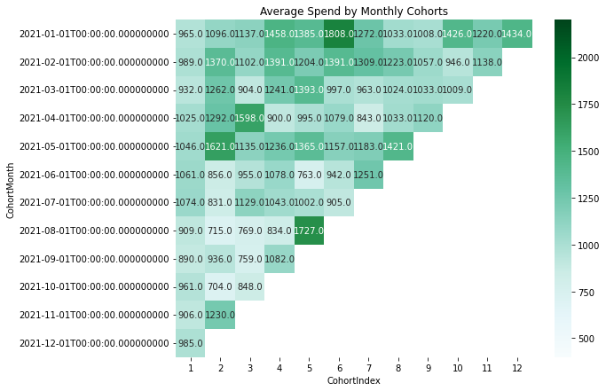

```python
# Initialize an 8 by 6 inches plot figure
plt.figure(figsize=(9, 7))

# Add a title
plt.title('Average Spend by Monthly Cohorts')

# Create the heatmap
sns.heatmap(average_price.round(0), fmt='0', vmin=399, vmax=2200, annot=True, cmap='BuGn')
plt.show()
```

```python
#Group customers by total money spend
sales_spend = sales.groupby(['Покупатель'])[['Покупатель', 'Сумма']].sum()

# Create a spend quartile with 4 groups - a range between 1 and 5
spend_quartile = pd.qcut(sales_spend['Сумма'], q=4, labels=range(1,5))

# Assign the quartile values to the Spend_Quartile column in data
sales_spend['Spend_Quartile'] = spend_quartile

# Print data with sorted Spend values
print(sales_spend.sort_values('Сумма'))
```

```
                                                        Сумма Spend_Quartile
Покупатель
Вavdvav22avzcfrlЮdfzcqwrlП23idvzcac24av                403.00              1
Су29dуac23dvft22avrlМavdvzcqw                          408.00              1
Ку26p24avrlО22fav24avrlЯdvdуfdfavaczcac24av            408.00              1
Куfidv23s22rlБdу25rfav24av                             408.00              1
Шacavdv21rlВavdf2324ip24av                             408.00              1
...                                                       ...            ...
А24avfiavfpqw                                        42464.00              4
#ИМЯ?                                                51584.60              4
А2424av                                              52724.99              4
6:0‚bARdIOЊ#BWFO^IOЊ$GYNBP]GNIY                      87923.00              4
ФОПrlПavdv26p24rlВavdf2324ip24rlГ232424avrft23a...  125654.00              4

[6267 rows x 2 columns]
```

```python
sales_recency = sales.groupby(['Покупатель'])[['Покупатель', 'CohortDay']].min()
```

```python
today = dt.datetime.today().strftime('%Y-%m-%d')
sales_recency['Today'] = today
sales_recency['Today'] = pd.to_datetime(sales_recency['Today'])


# Get the integers for date parts from the `InvoiceMonth` column
last_purchase_year, last_purchase_month, last_purchase_day = get_date_int(sales_recency, 'CohortDay')
today_year, today_month, today_day = get_date_int(sales_recency, 'Today')

# Calculate difference in years
years_diff2 = today_year - last_purchase_year

# Calculate difference in months
months_diff2 = today_month - last_purchase_month

# Calculate difference in day
day_diff2 = today_day - last_purchase_day

sales_recency['Recency_Days'] = years_diff2 * 365 + months_diff2 * 30 + day_diff2 + 1
sales_recency

sales_recency.head()
```

| Покупатель | Покупатель | CohortDay | Today | Recency_Days |
| --- | --- | --- | --- | --- |
| 0 | 0 | 2021-02-03 | 2022-02-06 | 369 |
| ZQBЊ&MQNB | ZQBЊ&MQNB | 2021-01-20 | 2022-02-06 | 382 |
| NSPP_LЊ/MQNB | NSPP_LЊ/MQNB | 2021-02-17 | 2022-02-06 | 355 |
| WILQPNA‚KNBЊ0G^QNNB | WILQPNA‚KNBЊ0G^QNNB | 2021-02-21 | 2022-02-06 | 351 |
| \FNQJY_K‚KNB | \FNQJY_K‚KNB | 2021-11-01 | 2022-02-06 | 101 |

```python
# Store labels from 4 to 1 in a decreasing order
r_labels = list(range(4, 0, -1))

# Create a spend quartile with 4 groups and pass the previously created labels
recency_quartiles = pd.qcut(sales_recency['Recency_Days'], q=4, labels=r_labels)

# Assign the quartile values to the Recency_Quartile column in `data`
sales_recency['Recency_Quartile'] = recency_quartiles

# Print `data` with sorted Recency_Days values
sales_recency.sort_values('Recency_Days')
```

| Покупатель | Покупатель | CohortDay | Today | Recency_Days | Recency_Quartile |
| --- | --- | --- | --- | --- | --- |
| Кf2324rf28dуacavrlОdft25avrlВp22idуdvdуac24av | Кf2324rf28dуacavrlОdft25avrlВp22idуdvdуac24av | 2021-12-31 | 2022-02-06 | 41 | 4 |
| Бzcdfdу2123dv22zcacft22avrlАdfzc24av | Бzcdfdу2123dv22zcacft22avrlАdfzc24av | 2021-12-31 | 2022-02-06 | 41 | 4 |
| Кdу28уmrlКavdvzc24av | Кdу28уmrlКavdvzc24av | 2021-12-31 | 2022-02-06 | 41 | 4 |
| Аdf2322fav24rfdv | Аdf2322fav24rfdv | 2021-12-31 | 2022-02-06 | 41 | 4 |
| Пavdvip22avrlОdf2324avrlОdf2322fzcїac24av | Пavdvip22avrlОdf2324avrlОdf2322fzcїac24av | 2021-12-30 | 2022-02-06 | 42 | 4 |
| ... | ... | ... | ... | ... | ... |
| 3QMGYA‚1KB^FRTNB | 3QMGYA‚1KB^FRTNB | 2021-01-02 | 2022-02-06 | 400 | 1 |
| $ZCLЊ!OYA | $ZCLЊ!OYA | 2021-01-02 | 2022-02-06 | 400 | 1 |
| 1LNYQNLZЃAYA‚, | 1LNYQNLZЃAYA‚, | 2021-01-01 | 2022-02-06 | 401 | 1 |
| &TEPdA‚,NOL | &TEPdA‚,NOL | 2021-01-01 | 2022-02-06 | 401 | 1 |
| ,Y`IQCBЊ)RTNB | ,Y`IQCBЊ)RTNB | 2021-01-01 | 2022-02-06 | 401 | 1 |

6267 rows × 5 columns

```python
snapshot_date = max(sales.InvoiceDay) + dt.timedelta(days=1)
```

```python
# Calculate Recency, Frequency and Monetary value for each customer
datamart = sales.groupby(['Покупатель']).agg({
    'InvoiceDay': lambda x: (snapshot_date - x.max()).days,
    'Номер': 'count',
    'Сумма': 'sum'})

# Rename the columns
datamart.rename(columns={'InvoiceDay': 'Recency',
                         'Номер': 'Frequency',
                         'Сумма': 'MonetaryValue'}, inplace=True)

datamart.describe()
```

|  | Recency | Frequency | MonetaryValue |
| --- | --- | --- | --- |
| count | 6267.000000 | 6267.000000 | 6267.000000 |
| mean | 178.970161 | 1.225467 | 1237.417259 |
| std | 109.199570 | 1.895129 | 2670.994944 |
| min | 1.000000 | 1.000000 | 403.000000 |
| 25% | 83.000000 | 1.000000 | 599.000000 |
| 50% | 177.000000 | 1.000000 | 799.000000 |
| 75% | 278.000000 | 1.000000 | 1300.000000 |
| max | 365.000000 | 81.000000 | 125654.000000 |

```python
# Max frequency and monetary value does not look like real customer behaviour.
# Droping rows that contains not useful information
datamart = datamart.loc[datamart['Frequency'] < 8]
datamart = datamart.loc[datamart['MonetaryValue'] < 5000]

datamart.describe()
```

|  | Recency | Frequency | MonetaryValue |
| --- | --- | --- | --- |
| count | 6191.000000 | 6191.000000 | 6191.000000 |
| mean | 180.268777 | 1.100791 | 1062.570008 |
| std | 108.871673 | 0.354775 | 674.536180 |
| min | 1.000000 | 1.000000 | 403.000000 |
| 25% | 85.000000 | 1.000000 | 599.000000 |
| 50% | 179.000000 | 1.000000 | 799.000000 |
| 75% | 280.000000 | 1.000000 | 1299.000000 |
| max | 365.000000 | 5.000000 | 4997.000000 |

```python
# Create labels for Recency, Frequency and Monetary Label
r_labels = range(3, 0, -1); f_labels = range(1, 4); m_labels = range(1, 4)

# Assign these labels to three equal percentile groups
r_groups = pd.qcut(datamart['Recency'].rank(method='first'), q=3, labels=r_labels)

# Assign these labels to three equal percentile groups
f_groups = pd.qcut(datamart['Frequency'].rank(method='first'), q=3, labels=f_labels)

# Assign these labels to three equal percentile groups
m_groups = pd.qcut(datamart['MonetaryValue'].rank(method='first'), q=3, labels=m_labels)

# Create new columns R and F
datamart = datamart.assign(R=r_groups.values, F=f_groups.values, M=m_groups.values)
datamart['RFM_Score'] = datamart[['R','F','M']].sum(axis=1)
```

```python
datamart.head()
```

| Покупатель | Recency | Frequency | MonetaryValue | R | F | M | RFM_Score |
| --- | --- | --- | --- | --- | --- | --- | --- |
| 0 | 332 | 1 | 1748.0 | 1 | 1 | 3 | 5 |
| ZQBЊ&MQNB | 346 | 1 | 2876.0 | 1 | 1 | 3 | 5 |
| NSPP_LЊ/MQNB | 318 | 1 | 799.0 | 1 | 1 | 2 | 4 |
| WILQPNA‚KNBЊ0G^QNNB | 314 | 1 | 1598.0 | 1 | 1 | 3 | 5 |
| \FNQJY_K‚KNB | 61 | 1 | 940.0 | 3 | 1 | 2 | 6 |

```python
# Define rfm_level function
def rfm_level(df):
    if df['RFM_Score'] >= 9:
        return 'Top'
    elif ((df['RFM_Score'] >= 6) and (df['RFM_Score'] < 9)):
        return 'Middle'
    else:
        return 'Low'

# Create a new variable RFM_Level
datamart['RFM_Level'] = datamart.apply(rfm_level, axis=1)

# Print the header with top 5 rows
datamart.head()
```

| Покупатель | Recency | Frequency | MonetaryValue | R | F | M | RFM_Score | RFM_Level |
| --- | --- | --- | --- | --- | --- | --- | --- | --- |
| 0 | 332 | 1 | 1748.0 | 1 | 1 | 3 | 5 | Low |
| ZQBЊ&MQNB | 346 | 1 | 2876.0 | 1 | 1 | 3 | 5 | Low |
| NSPP_LЊ/MQNB | 318 | 1 | 799.0 | 1 | 1 | 2 | 4 | Low |
| WILQPNA‚KNBЊ0G^QNNB | 314 | 1 | 1598.0 | 1 | 1 | 3 | 5 | Low |
| \FNQJY_K‚KNB | 61 | 1 | 940.0 | 3 | 1 | 2 | 6 | Middle |

```python
datamart.groupby('RFM_Score').size().sort_values(ascending=False)[:10]
```

```
RFM_Score
7    1259
5    1140
6    1125
8     951
4     739
3     579
9     398
dtype: int64
```

```python
# Calculate average values for each RFM_Level, and return a size of each segment
rfm_level_agg = datamart.groupby('RFM_Level').agg({
    'Recency': 'mean',
    'Frequency': 'mean',
    'MonetaryValue': ['mean', 'count']
}).round(1)

# Print the aggregated dataset
print(rfm_level_agg)
```

```
          Recency Frequency MonetaryValue
             mean      mean          mean count
RFM_Level
Low         267.0       1.0         824.5  2458
Middle      131.2       1.1        1134.8  3335
Top          55.4       1.7        1927.5   398
```

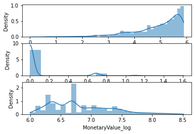

```python
datamart['Recency_log'] = np.log(datamart['Recency'])
datamart['Frequency_log'] = np.log(datamart['Frequency'])
datamart['MonetaryValue_log'] = np.log(datamart['MonetaryValue'])

# Plot distribution of var1
plt.subplot(3, 1, 1); sns.histplot(datamart['Recency_log'], kde=True, stat="density", linewidth=0)

# Plot distribution of var2
plt.subplot(3, 1, 2); sns.histplot(datamart['Frequency_log'], kde=True, stat="density", linewidth=0)

# Plot distribution of var3
plt.subplot(3, 1, 3); sns.histplot(datamart['MonetaryValue_log'], kde=True, stat="density", linewidth=0)

# Show the plot
plt.show()
```

```python
datamart.describe()
```

|  | Recency | Frequency | MonetaryValue | RFM_Score | Recency_log | Frequency_log | MonetaryValue_log |
| --- | --- | --- | --- | --- | --- | --- | --- |
| count | 6191.000000 | 6191.000000 | 6191.000000 | 6191.000000 | 6191.000000 | 6191.000000 | 6191.000000 |
| mean | 180.268777 | 1.100791 | 1062.570008 | 6.000000 | 4.872316 | 0.065255 | 6.823359 |
| std | 108.871673 | 0.354775 | 674.536180 | 1.702986 | 0.987152 | 0.218700 | 0.507949 |
| min | 1.000000 | 1.000000 | 403.000000 | 3.000000 | 0.000000 | 0.000000 | 5.998937 |
| 25% | 85.000000 | 1.000000 | 599.000000 | 5.000000 | 4.442651 | 0.000000 | 6.395262 |
| 50% | 179.000000 | 1.000000 | 799.000000 | 6.000000 | 5.187386 | 0.000000 | 6.683361 |
| 75% | 280.000000 | 1.000000 | 1299.000000 | 7.000000 | 5.634790 | 0.000000 | 7.169350 |
| max | 365.000000 | 5.000000 | 4997.000000 | 9.000000 | 5.899897 | 1.609438 | 8.516593 |

```python
datamart_rfm = datamart[['Recency', 'Frequency', 'MonetaryValue']]
datamart_centred = datamart_rfm - datamart_rfm.mean()
datamart_centred.describe().round(2)
```

|  | Recency | Frequency | MonetaryValue |
| --- | --- | --- | --- |
| count | 6191.00 | 6191.00 | 6191.00 |
| mean | 0.00 | 0.00 | 0.00 |
| std | 108.87 | 0.35 | 674.54 |
| min | -179.27 | -0.10 | -659.57 |
| 25% | -95.27 | -0.10 | -463.57 |
| 50% | -1.27 | -0.10 | -263.57 |
| 75% | 99.73 | -0.10 | 236.43 |
| max | 184.73 | 3.90 | 3934.43 |

```python
datamart_scaled = datamart_rfm / datamart_rfm.std()
datamart_scaled.describe().round(2)
```

|  | Recency | Frequency | MonetaryValue |
| --- | --- | --- | --- |
| count | 6191.00 | 6191.00 | 6191.00 |
| mean | 1.66 | 3.10 | 1.58 |
| std | 1.00 | 1.00 | 1.00 |
| min | 0.01 | 2.82 | 0.60 |
| 25% | 0.78 | 2.82 | 0.89 |
| 50% | 1.64 | 2.82 | 1.18 |
| 75% | 2.57 | 2.82 | 1.93 |
| max | 3.35 | 14.09 | 7.41 |

```python
scaler = StandardScaler()
scaler.fit(datamart_rfm)
datamart_normalized = scaler.transform(datamart_rfm)
print('mean: ', datamart_normalized.mean(axis=0).round(2))
print('std: ', datamart_normalized.std(axis=0).round(2))
```

```
mean:  [0. 0. 0.]
std:  [1. 1. 1.]
```

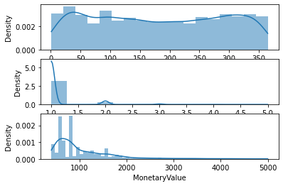

```python
# Plot recency distribution
plt.subplot(3, 1, 1); sns.histplot(datamart_rfm['Recency'], kde=True, stat="density", linewidth=0)

# Plot frequency distribution
plt.subplot(3, 1, 2); sns.histplot(datamart_rfm['Frequency'], kde=True, stat="density", linewidth=0)

# Plot monetary value distribution
plt.subplot(3, 1, 3); sns.histplot(datamart_rfm['MonetaryValue'], kde=True, stat="density", linewidth=0)

# Show the plot
plt.show()
```

```python
datamart_log = np.log(datamart_rfm)
scaler.fit(datamart_log)
daramart_normalized = scaler.transform(datamart_log)
datamart_normalized = pd.DataFrame(data=datamart_normalized, index=datamart_rfm.index, columns=datamart_rfm.columns)
```

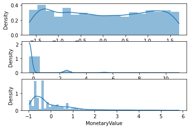

```python
# Plot recency distribution
plt.subplot(3, 1, 1); sns.histplot(datamart_normalized['Recency'], kde=True, stat="density", linewidth=0)

# Plot frequency distribution
plt.subplot(3, 1, 2); sns.histplot(datamart_normalized['Frequency'], kde=True, stat="density", linewidth=0)

# Plot monetary value distribution
plt.subplot(3, 1, 3); sns.histplot(datamart_normalized['MonetaryValue'], kde=True, stat="density", linewidth=0)

# Show the plot
plt.show()
```

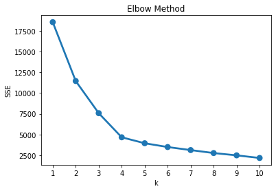

```python
sse={}
for k in range(1, 11):
    kmeans = KMeans(n_clusters=k, random_state=1)
    kmeans.fit(daramart_normalized)
    sse[k] = kmeans.inertia_
plt.title('Elbow Method')
plt.xlabel('k'); plt.ylabel('SSE')
sns.pointplot(x=list(sse.keys()), y=list(sse.values()))
plt.show()
```

```python
kmeans = KMeans(n_clusters=4, random_state=1)
kmeans.fit(daramart_normalized)
cluster_labels = kmeans.labels_
datamart_rfm_k2 = datamart_rfm.assign(Cluster = cluster_labels)
datamart_rfm_k2.groupby(['Cluster']).agg({'Recency': 'mean', 'Frequency': 'mean', 'MonetaryValue': ['mean', 'count']}).round(0)
```

| Cluster | Recency mean | Frequency mean | MonetaryValue mean | MonetaryValue count |
| --- | --- | --- | --- | --- |
| 0 | 34.0 | 1.0 | 885.0 | 1129 |
| 1 | 140.0 | 2.0 | 2088.0 | 531 |
| 2 | 225.0 | 1.0 | 650.0 | 2929 |
| 3 | 215.0 | 1.0 | 1602.0 | 1602 |

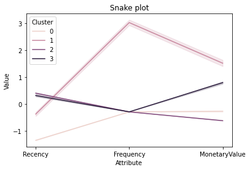

```python
datamart_normalized = pd.DataFrame(datamart_normalized, index=datamart_rfm.index, columns=datamart_rfm.columns)
datamart_normalized['Cluster'] = datamart_rfm_k2['Cluster']
datamart_melt = pd.melt(datamart_normalized.reset_index(), id_vars=['Покупатель', 'Cluster'], value_vars=['Recency', 'Frequency', 'MonetaryValue'], var_name='Attribute', value_name='Value')
plt.title('Snake plot')
sns.lineplot(x='Attribute', y='Value', hue='Cluster', data=datamart_melt)
```

```python
cluster_avg = datamart_rfm_k2.groupby(['Cluster']).mean()
population_avg = datamart_rfm.mean()
relative_imp = cluster_avg / population_avg - 1
relative_imp.round(2)
```

| Cluster | Recency | Frequency | MonetaryValue |
| --- | --- | --- | --- |
| 0 | -0.81 | -0.09 | -0.17 |
| 1 | -0.22 | 0.98 | 0.97 |
| 2 | 0.25 | -0.09 | -0.39 |
| 3 | 0.19 | -0.09 | 0.51 |

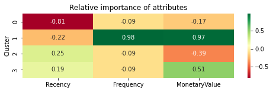

```python
# Initialize an 8 by 6 inches plot figure
plt.figure(figsize=(8, 2))

# Add a title
plt.title('Relative importance of attributes')

# Create the heatmap
sns.heatmap(relative_imp.round(2), fmt='.2f', annot=True, cmap='RdYlGn')
plt.show()
```

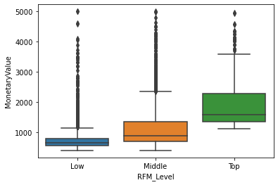

```python
sns.boxplot(x='RFM_Level', y='MonetaryValue', data=datamart)
```

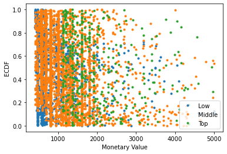

```python
datamart_low = np.array(datamart.loc[datamart['RFM_Level'] == 'Low'][['MonetaryValue']])
datamart_middle = np.array(datamart.loc[datamart['RFM_Level'] == 'Middle'][['MonetaryValue']])
datamart_top = np.array(datamart.loc[datamart['RFM_Level'] == 'Top'][['MonetaryValue']])


def ecdf(data):
    """Compute ECDF for a one-dimensional array of measurements."""
    # Number of data points: n
    n = len(data)

    # x-data for the ECDF: x
    x = np.sort(data)

    # y-data for the ECDF: y
    y = np.arange(1, n+1) / n

    return x, y

# Compute ECDFs
x_set, y_set = ecdf(datamart_low)
x_vers, y_vers = ecdf(datamart_middle)
x_virg, y_virg = ecdf(datamart_top)

# Plot all ECDFs on the same plot
_ = plt.plot(x_set, y_set, marker='.', linestyle='none')
_ = plt.plot(x_vers, y_vers, marker='.', linestyle='none')
_ = plt.plot(x_virg, y_virg, marker='.', linestyle='none')

# Annotate the plot
_ = plt.legend(('Low', 'Middle', 'Top'), loc='lower right')
_ = plt.xlabel('Monetary Value')
_ = plt.ylabel('ECDF')

# Display the plot
plt.show()
```